# Clustering

Giuliano

03/01/2021

**Nota importante**: este script ha sido programado tomando como referencia la práctica de la lección 5 de la asignatura sobre aprendizaje no supervisado. Además, también se han explorado referencias como la documentación de R del [paquete cluster](https://www.rdocumentation.org/packages/cluster/versions/2.1.0/topics/silhouette) y algunos ejemplos de interés en otros [forums](https://medium.com/codesmart/r-series-k-means-clustering-silhouette-794774b46586).

## Introducción

En este documento se tratará de estudiar la técnica de *clustering*, también conocida como *k-means*, tanto en su versión simple, como en la versión jerárquica. Se reutilizará el conocimiento adquirido por el análisis *PCA* para explorar las diferencias entre el dataset original escalado y el dataset de componentes principales. Por último, también se esudiará el impacto que tiene la elección del número `k` sobre la bondad de los resultados de ésta técnica.

En primer lugar, se carga la librería `cluster`, que nos proporcionará más adelante el método `silhouette`, y se declaran algunas variables útiles:

```r
library(cluster)

SAVE_PATH <- "../data/clustering/"
binary_columns <- c("anaemia", "diabetes", "high_blood_pressure", "sex", "smoking", "death")
```

```r
df <- read.csv("../data/heart_failure.csv")
scaled_df <- data.frame(scale(df))
head(df)
```

|  | age | anaemia | creatinine_phosphokinase | diabetes | ejection_fraction | high_blood_pressure | platelets | serum_creatinine | serum_sodium | sex | smoking | time | death |
| --- | --- | --- | --- | --- | --- | --- | --- | --- | --- | --- | --- | --- | --- |
| 1 | 75 | 0 | 582 | 0 | 20 | 1 | 265000 | 1.9 | 130 | 1 | 0 | 4 | 1 |
| 2 | 55 | 0 | 7861 | 0 | 38 | 0 | 263358 | 1.1 | 136 | 1 | 0 | 6 | 1 |
| 3 | 65 | 0 | 146 | 0 | 20 | 0 | 162000 | 1.3 | 129 | 1 | 1 | 7 | 1 |
| 4 | 50 | 1 | 111 | 0 | 20 | 0 | 210000 | 1.9 | 137 | 1 | 0 | 7 | 1 |
| 5 | 65 | 1 | 160 | 1 | 20 | 0 | 327000 | 2.7 | 116 | 0 | 0 | 8 | 1 |
| 6 | 90 | 1 | 47 | 0 | 40 | 1 | 204000 | 2.1 | 132 | 1 | 1 | 8 | 1 |

## Clustering Simple

Comenzando con la funcionalidad a implementar, en primer lugar, se definirá una función genérica para hacer un plot de todas las combinaciones posibles de pares de columnas, para luego poder seleccionar manualmente las gráficas de mayor interés. Aunque el clustering puede hacerse considerando más columnas, únicamente cuando tiene sentido hacer una gráfica tomándolas de dos en dos.

```r
clustering <- function(dataframe, k, columns) {
  km_df <- subset(dataframe, select = columns)
  km <- kmeans(km_df, center=k, nstart=50)
  plot(km_df, col=km$cluster, main=paste(columns[1], " y ", columns[2], "con ", k, " clusters"))
}

plot_clustering <- function(dataframe, k, save_path) {
  for (column1 in names(dataframe)) {
    for (column2 in names(dataframe)) {
      if (column2 != column1) {
        plot_filename <- paste(SAVE_PATH, save_path, column1, "_", column2, "_", "k_", k, ".png", sep = "")
        png(filename=plot_filename)
        clustering(dataframe, k, c(column1, column2))
        dev.off()
      }
    }
  }
}
```

```r
kmeans_df <- subset(scaled_df, select = setdiff(names(scaled_df), binary_columns))
plot_clustering(kmeans_df, k = 3, "simple/")
```

## Aprovechando el PCA

Haciendo uso del conocimiento que hemos extraído del análisis PCA, vamos a aplicar clustering sobre el dataset de componentes principales, tomando únicamente las columnas que garanticen un $90%$ de variabilidad, es decir, 10.

```r
pca <- prcomp(df, scale=TRUE, center=TRUE)
pca <- pca$x[,1:10]
plot_clustering(pca, k=5, "pca/")
```

El dataframe obtenido por *PCA* genera clusters que a primera vista parecen más significativos que los generados por el simple dataframe escalado. Véase el siguiente ejemplo:

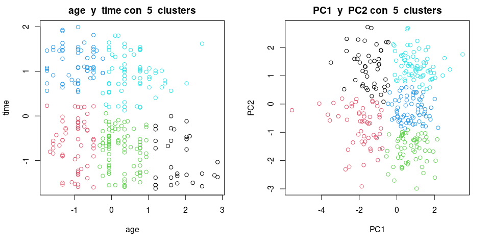

```r
par(mfrow = c(1, 2))
clustering(scaled_df, 5, c("age", "time"))
clustering(pca, 5, c("PC1", "PC2"))
```

Esto parece sensato, ya que precisamente el *PCA* se encarga de extraer columnas nuevas fruto de combinación lineal de las originales de forma que exista variabilidad y sean relevantes.

## Clustering Jerárquico

A continuación, vamos a definir una función que implemente el clustering jerárquico de forma genérica:

```r
plot_h_clustering <- function(dataframe, save_name) {
  for (m in c("complete", "average", "single")) {
    hclust <- hclust(dist(dataframe), method = m)
    png(filename=paste(SAVE_PATH, "jerarquico/", save_name, "_", "distance_", m, ".png", sep = ""))
    plot(hclust, main = paste("Hclustering de ", save_name, ". dist: '", m, "'", sep=""))
    dev.off()
    plot(hclust, main = paste("Hclustering de ", save_name, ". dist: '", m, "'", sep=""))
  }
}
```

Invocamos la función para los tres posibles dataframes que tenemos:

```r
par(mfrow = c(3, 3))
plot_h_clustering(df, "raw")
plot_h_clustering(scaled_df, "scaled")
```

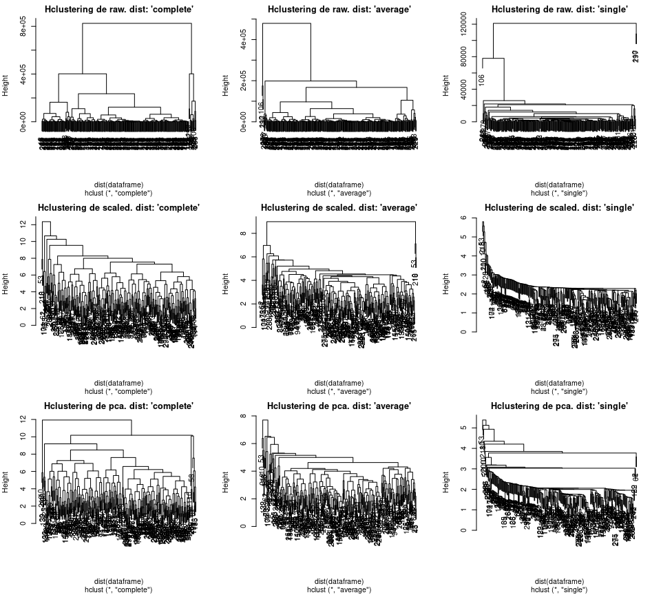

```r
plot_h_clustering(pca, "pca")
```

Debido al número de instancias del dataset (299), la visualización del clustering jerárquico es algo pobre, y aporta poca información. Visto de cerca, el clustering jerárquico quedaría algo como esto:

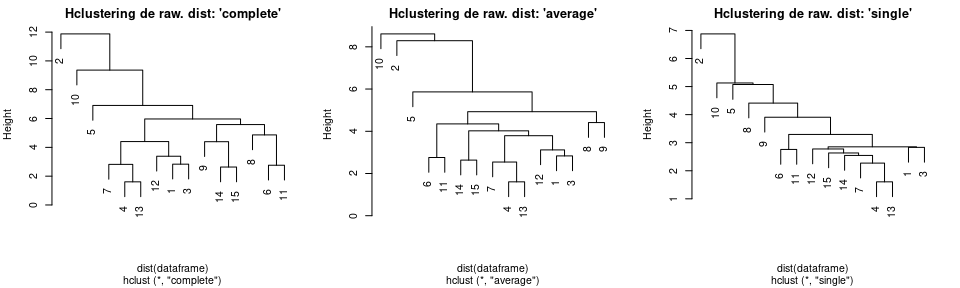

```r
par(mfrow = c(1, 3))
plot_h_clustering(pca[1:15, 1:10], "raw")
```

## Silhouette

```r
compute_silhouette <- function(dataframe, k){
  km <- kmeans(dataframe, centers = k, nstart=50)
  sil <- silhouette(km$cluster, dist(dataframe))
  mean(sil[, 3])
}

plot_silhouette_by_centers <- function(dataframe, save_name){
  centers <- 2:10
  mean_sil <- sapply(centers, compute_silhouette, dataframe=dataframe)
  plot_filename <- paste(SAVE_PATH, "silhouette/", save_name, "_silhouette_evolution.png", sep = "")
  png(filename=plot_filename)
  plot(centers, type='b', mean_sil, main= paste(save_name, " silhouette evolution", sep=""), xlab='k', ylab='Silhouette', frame=FALSE)
  dev.off()
  plot(centers, type='b', mean_sil, main= paste(save_name, " silhouette evolution", sep=""), xlab='k', ylab='Silhouette', frame=FALSE)
}
```

Y ahora la invocamos sobre el dataframe original, el escalado, y el de componentes principales:

```r
par(mfrow = c(1, 3))
plot_silhouette_by_centers(scaled_df, "scaled")
plot_silhouette_by_centers(df, "raw")
```

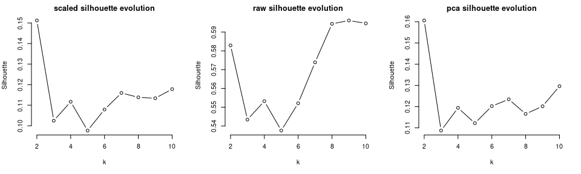

```r
plot_silhouette_by_centers(pca, "pca")
```

## Conclusión

En este estudio hemos demostrado un caso de uso para la técnica de aprendizaje no supervisado de *clustering*, explorando las diferentes opciones propuestas en la introducción. Ulteriores gráficos pueden verse en `data/clustering/`.